# Reproducible Research: Peer Assessment 1

Dawit Aberra

Tuesday, October 14, 2014

## Loading and preprocessing the data

1. The code that is needed to download the data is

```r
download.file("https://d396qusza40orc.cloudfront.net/repdata%2Fdata%2Factivity.zip","activity/fakename.csv")
```

Read the data to R. Warning…if the data is still in your “activity.zip”, you need to unzip the data manually to a folder called “activity” in your working directory before reading to R!

```r
data<-read.csv("activity/activity.csv")
```

2. We removing NAs for convenience, and call the processed/transformed data “datap”.

```r
datap<-subset(data,data$steps!="NA")
```

## What is mean total number of steps taken per day?

For this part of the assignment, we ignored the missing values in the dataset.

1. A histogram of the total number of steps taken each day is

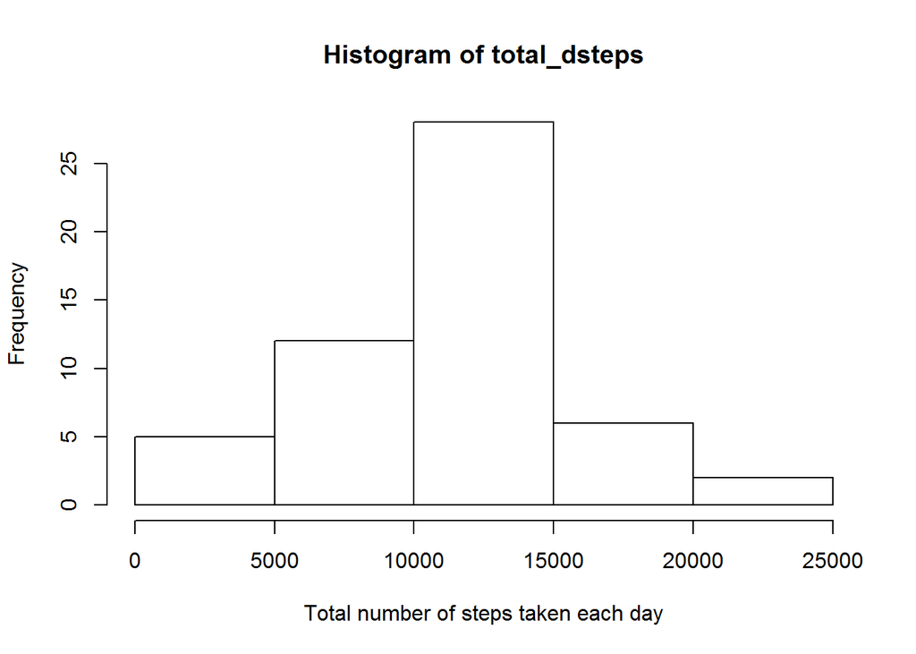

```r
total_dsteps<-tapply(datap$steps,datap$date,sum)
hist(total_dsteps,xlab = "Total number of steps taken each day")
```

2. The mean and median total number of steps taken per day are

```r
mean_dsteps<-mean(total_dsteps,na.rm=TRUE)
mean_dsteps
```

```
## [1] 10766
```

```r
median_dsteps<-median(total_dsteps,na.rm=TRUE)
median_dsteps
```

```
## [1] 10765
```

## What is the average daily activity pattern?

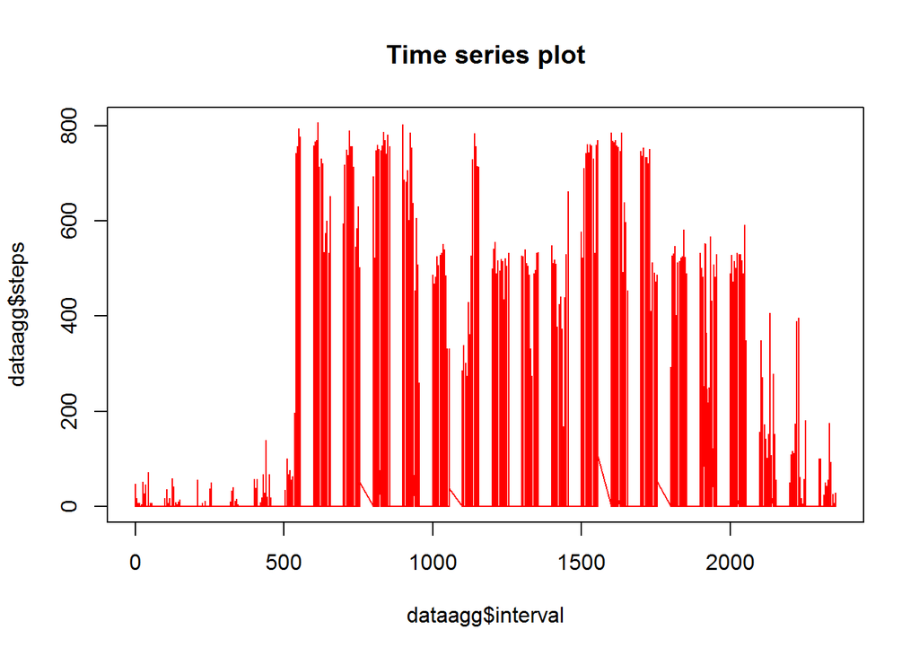

```r
options(warn=-1)
dataagg<-aggregate(datap, by=list(date=datap$date,interval=datap$interval),FUN=mean,na.rm=TRUE)
plot(dataagg$interval,dataagg$steps, type = "l",main = "Time series plot",col = "red")
```

```r
subdataagg<-subset(dataagg, dataagg$steps==max(dataagg$steps))
interval<-subdataagg$interval
interval
```

```
## [1] 615
```